# IRD/CIRAD trainning to R, the statistical programming language

Sept. 7-11, 2015

## Updated tentative program of the week

## J1 - Generalities on R

- Short overview of R distributions, installation and packages
- Finding, requesting and understanding R help: surfing a sea of resources
- Writing and managing your R code
- Getting to know the R IDE `Rstudio`
- Introduction to Sweave et knitr
- Data structure in R: vectors, factors, matrces, data frames and lists
- Mathematical and statistical computations on numeric and logical vectors: basic functions and operators
- Data manipulation I: play with the vector and make it your toy

## J2 - R programming

- Data manipulation II: be the master of arrays (matrices), lists and data frames
- Writting and calling functions in R
- An introduction to object-oriented programming in R: S3 classes and generic functions
- Loops and conditional execution.
- Character strings manipulation
- The basics of R – operating system interactions

## J3 - Graphics

- R Graphics: low- and high-level graphical functions and graphical parameters (`par()`)
- The `lattice` and `ggplot2` packages
- A few examples of specific graphical functionalities

## J4 - Statistics

- Linerar models: simple regression, multiple regression , ANOVA, ANCOVA, statistical tests, formulas, continuous and descrete predictors, interactions.
- Generalized linear models (GLM) : distributions, maximum likelyhood, statistical tests

## J5 -

- Workshop on your own projects/data
- Discussion on difficulties/common problems and possible solutions

## Short overview of R distributions, installation and packages

[figure not shown]

## Comprehensive R Archive Network (CRAN)

*R is a system for statistical computation and graphics. It consists of a **language** plus a **run-time environment** with graphics, a debugger, access to certain system functions, and the ability to run programs stored in script files.*

https://www.r-project.org/

R version 3.2.2 (Fire Safety) has been released on 2015-08-14.

There are R distributions for Linux, Mac, Windows… platforms.

Installation procedure for your favorite platform should be straigthforward if you follow the [instructions](https://cran.r-project.org/doc/FAQ/R-FAQ.html#How-can-R-be-installed_003f) from CRAN.

On Windows, upgrading R versions may be a pain, but see the [R Windows FAQ](https://cran.r-project.org/bin/windows/base/rw-FAQ.html#What_0027s-the-best-way-to-upgrade_003f).

On linux systems, in my experience the most straightforward way to be kept up-to-date, is [to register a CRAN repository in your favorite package manager](https://cran.r-project.org/bin/linux/ubuntu/README.html).

## Our first interactions with R

- R is a lot of things but from a user perspective apart from a language, it is primarily:
  - an interpreter that interactively executes the commands you wrote at the prompt upon pressing the enter key.
  - a Graphical display that opens windows (devices) to display graphics created by executing some code.
- First start R if not done already and let’s try to open a graphical window :

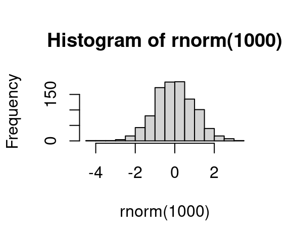

```r
hist(rnorm(1000))
```

- Now let’s execute a few simple expressions in the interpreter to warm up your fingers

```r
1 + 1

# 124é"famoi'_(ù*$=+" - Use a hash '#' to add comments that are just ignored

a <- "hello" # assigning a value to a symbol/name
A <- 1

# If you simply enter the variable name or expression at the command prompt,
# R will PRINT its value.
a
A

2 <- "error"

?Reserved

B <- 2
A + B

C <- c(A, B)
C
```

```r
mode(C)

log(x=64, base=4) # reminder about functions and parameters
log(64, 4)

# Missing data
y <- c(1,2,3,NA)
is.na(y) # returns a vector (F F F T)

# Not A Number
sqrt(-9)

# close your session
q()
```

Does this sound familiar to all of you?

## R packages are the standardized way of extending R

- The standard R distribution comes with an amazing number of tools but one may need to perform specific tasks.
- To extend R functionalities you will want to download and install additional *packages* and use them.
- **Packages** (libraries, modules, … in other languages) are collections of R functions, data, and compiled code in a well-defined format. The directory where packages are stored is called the **library**.
- The standard distribution comes with several packages (`base`, `compiler`, `datasets`, `grDevices`, `graphics`, …)
- Repositories hold collections of R packages and have mecanisms to download and install them on your system (99% of the time, it is really easy).
- “Mainstream” repositories are CRAN, the [Omega project](http://www.omegahat.org/) and Bioconductor.

## Package repositories and installation

- The primary repository is CRAN. It holds about **7000** (!!!) packages. The easiest way to install from CRAN is just to use `install.packages("packageName")`

```r
# Try and install:
install.packages(c("ape", "devtools"))
```

- Another popular repository is

[figure not shown]

[Bioconductor](https://www.bioconductor.org/) is *bioinformatics-oriented*

- It supports many types of high-throughput sequencing data (DNA, RNA, chIP, methylomes and ribosome profiling, …) and associated annotation resources and covers mircroarrays, proteomic, metabolomic, flow cytometry, quantitative imaging, cheminformatic and other high-throughput data :
  - 1024 software packages
  - 241 experiment data packages
  - 917 up-to-date annotation packages.
- [To install Bioconductor packages](https://www.bioconductor.org/install/) the procedure is different:

```r
source("http://bioconductor.org/biocLite.R") # fetch and execute code of the  function:
biocLite("packageName")
```

- GitHub is becoming increasingly popular as a repository for R packages:  
  First install `devtools` from CRAN (!…) and then call the `devtools::install_github()` function.
- To remove packages: `remove.packages(pkgs="packageName")`

## Using packages

- To know what packages are installed on your system: `installed.packages()`
- To use resources from a package, you generally **attach** it to your working environment with `library()` (or `require()`). This will *load* the ressources from the package in memory and *attach* it to your `search()` path.

```r
search() # list of attached R packages and objects
## [1] ".GlobalEnv"        "package:stats"     "package:graphics"
## [4] "package:grDevices" "package:utils"     "package:datasets"
## [7] "package:methods"   "Autoloads"         "package:base"
library(ape) # or
library("ape")
search()
##  [1] ".GlobalEnv"        "package:ape"       "package:stats"
##  [4] "package:graphics"  "package:grDevices" "package:utils"
##  [7] "package:datasets"  "package:methods"   "Autoloads"
## [10] "package:base"
```

- When would you just want to *load* a package:
  - if just need a quick function to avoid crowding unecessarily your seach path (decrease perf and may create name conflicts).
  - overcome name conflicts by specifying where to find the object.

```r
session_info() # This function is from devtools but is not loaded
## Error in session_info(): could not find function "session_info"
devtools::session_info() # loads devtools if not already done and call session_info()
## ─ Session info ───────────────────────────────────────────────────────────────
##  setting  value
##  version  R version 4.4.1 (2024-06-14)
##  os       Ubuntu 22.04.4 LTS
##  system   x86_64, linux-gnu
##  ui       X11
##  language en_US:en
##  collate  en_US.UTF-8
##  ctype    en_US.UTF-8
##  tz       Europe/Paris
##  date     2024-09-11
##  pandoc   3.1.11 @ /usr/lib/rstudio/resources/app/bin/quarto/bin/tools/x86_64/ (via rmarkdown)
##
## ─ Packages ───────────────────────────────────────────────────────────────────
##  package     * version date (UTC) lib source
##  ape         * 5.8     2024-04-11 [1] CRAN (R 4.4.0)
##  bslib         0.7.0   2024-03-29 [1] CRAN (R 4.4.0)
##  cachem        1.0.8   2023-05-01 [1] CRAN (R 4.4.0)
##  cli           3.6.2   2023-12-11 [1] CRAN (R 4.4.0)
##  devtools      2.4.5   2022-10-11 [1] CRAN (R 4.4.0)
##  digest        0.6.35  2024-03-11 [1] CRAN (R 4.4.0)
##  ellipsis      0.3.2   2021-04-29 [1] CRAN (R 4.4.0)
##  evaluate      0.23    2023-11-01 [1] CRAN (R 4.4.0)
##  fastmap       1.1.1   2023-02-24 [1] CRAN (R 4.4.0)
##  fs            1.6.4   2024-04-25 [1] CRAN (R 4.4.0)
##  glue          1.7.0   2024-01-09 [1] CRAN (R 4.4.0)
##  highr         0.10    2022-12-22 [1] CRAN (R 4.4.0)
##  htmltools     0.5.8.1 2024-04-04 [1] CRAN (R 4.4.0)
##  htmlwidgets   1.6.4   2023-12-06 [1] CRAN (R 4.4.0)
##  httpuv        1.6.15  2024-03-26 [1] CRAN (R 4.4.0)
##  jquerylib     0.1.4   2021-04-26 [1] CRAN (R 4.4.0)
##  jsonlite      1.8.8   2023-12-04 [1] CRAN (R 4.4.0)
##  knitr         1.46    2024-04-06 [1] CRAN (R 4.4.0)
##  later         1.3.2   2023-12-06 [1] CRAN (R 4.4.0)
##  lattice       0.22-6  2024-03-20 [1] CRAN (R 4.4.0)
##  lifecycle     1.0.4   2023-11-07 [1] CRAN (R 4.4.0)
##  magrittr      2.0.3   2022-03-30 [1] CRAN (R 4.4.0)
##  memoise       2.0.1   2021-11-26 [1] CRAN (R 4.4.0)
##  mime          0.12    2021-09-28 [1] CRAN (R 4.4.0)
##  miniUI        0.1.1.1 2018-05-18 [1] CRAN (R 4.4.0)
##  nlme          3.1-164 2023-11-27 [1] CRAN (R 4.4.0)
##  pkgbuild      1.4.4   2024-03-17 [1] CRAN (R 4.4.0)
##  pkgload       1.3.4   2024-01-16 [1] CRAN (R 4.4.0)
##  profvis       0.3.8   2023-05-02 [1] CRAN (R 4.4.0)
##  promises      1.3.0   2024-04-05 [1] CRAN (R 4.4.0)
##  purrr         1.0.2   2023-08-10 [1] CRAN (R 4.4.0)
##  R6            2.5.1   2021-08-19 [1] CRAN (R 4.4.0)
##  Rcpp          1.0.12  2024-01-09 [1] CRAN (R 4.4.0)
##  remotes       2.5.0   2024-03-17 [1] CRAN (R 4.4.0)
##  rlang         1.1.3   2024-01-10 [1] CRAN (R 4.4.0)
##  rmarkdown     2.26    2024-03-05 [1] CRAN (R 4.4.0)
##  rstudioapi    0.16.0  2024-03-24 [1] CRAN (R 4.4.0)
##  sass          0.4.9   2024-03-15 [1] CRAN (R 4.4.0)
##  sessioninfo   1.2.2   2021-12-06 [1] CRAN (R 4.4.0)
##  shiny         1.8.1.1 2024-04-02 [1] CRAN (R 4.4.0)
##  stringi       1.8.3   2023-12-11 [1] CRAN (R 4.4.0)
##  stringr       1.5.1   2023-11-14 [1] CRAN (R 4.4.0)
##  urlchecker    1.0.1   2021-11-30 [1] CRAN (R 4.4.0)
##  usethis       2.2.3   2024-02-19 [1] CRAN (R 4.4.0)
##  vctrs         0.6.5   2023-12-01 [1] CRAN (R 4.4.0)
##  xfun          0.43    2024-03-25 [1] CRAN (R 4.4.0)
##  xtable        1.8-4   2019-04-21 [1] CRAN (R 4.4.0)
##  yaml          2.3.8   2023-12-11 [1] CRAN (R 4.4.0)
##
##  [1] /home/cunnac/R/x86_64-pc-linux-gnu-library/4.4
##  [2] /usr/local/lib/R/site-library
##  [3] /usr/lib/R/site-library
##  [4] /usr/lib/R/library
##
## ──────────────────────────────────────────────────────────────────────────────
# run ?"::" if you want.
```

- To only `detach("package:ape")` a package does not unload it.  
  For this, you will need `unloadNamespace("ape")`  
  In practice this is barely used.

## Exercice

We are probably going to need the following packages: “ape”, “reshape2”, “dplyr”, “lattice”, “ggplot2”, “VennDiagram”.

- These should be hostetd on CRAN. Install them on your system.

```r
install.packages(c("ape", "reshape2", "dplyr", "lattice", "ggplot2", "VennDiagram"))
```

- “Biostrings” is a Bioconductor package. Please, install it as well.

```r
source("http://bioconductor.org/biocLite.R") # fetch and execute code of the  function:
biocLite("Biostrings")
```

- Test if you can use them with `library()`

Please, let us know if anything weird happened.

## Finding, requesting and understanding R help: surfing a sea of resources.

Clearly, one R’s distinctive feature is that documentation ressources in broad terms are extremely aboundant:

- **R’s documentation**: traditionally, the R developpers commmunity emphasized writing extensive help documents.
- **Books, tutorials, discussions**: R users base is pretty large and online community is very active.

## Searching your local R documentation for help on a topic:

- If you have a specific name in mind: Documentation on a topic with name (typically, a R object or a data set)
  - `help("name")` or `?name` : **Beware**, `help()` searches only in loaded packages.
  - `help.start()` : starts the HTML version of help()

```r
?summary
```

- If you look for a topic and do not know the function: Search the **LOCAL** help system documentation matching a given character string in the name, alias, title, concept or keyword fields
  - `help.search("topic")` or `??topic`

```r
??"\\{"
??DNA
```

## Anatomy of a R function documentation page

- To illustrate the various sections of a function doucumentation, let’s type

```r
?paste
```

- To take a look at an example documentation for a dataset:

```r
?iris
```

- Cool functions:

```r
example("paste") # Run the code in the "examples" section of a function doc
demo("graphics") # some packages offer a demo of their functionalities!
```

## R Reference Card or Cheat Sheet

Cheat sheets are very convenient especially when you are not familiar with a language or a package:

- they remind you of specific aspects
- they are a great overview of what you can do.

https://cran.r-project.org/doc/contrib/Short-refcard.pdf

If you can open it, find functions that may help you find help…

## R manuals, tutorials, books : references used to prepare the slides

- *In English*:  
  Hands-On Programming with R http://shop.oreilly.com/product/0636920028574.do  
  The Art of R Programming https://www.nostarch.com/artofr.htm earlier free version at http://heather.cs.ucdavis.edu/~matloff/132/NSPpart.pdf  
  Advanced R http://adv-r.had.co.nz/  
  Datat Manipulation with R http://www.springer.com/us/book/9780387747309  
  An introduction to R http://cran.stat.auckland.ac.nz/doc/manuals/R-intro.pdf  
  R Bootcamp http://jaredknowles.com/r-bootcamp/  
  STATS 782 https://www.stat.auckland.ac.nz/~dscott/782/  
  R and Bioconductor by Thomas Girke http://manuals.bioinformatics.ucr.edu/
- *In French*:  
  R pour les débutants de E. Paradis https://cran.r-project.org/doc/contrib/Paradis-rdebuts_fr.pdf  
  Dia de formation d’E. Paradis http://ape-package.ird.fr/ep/teaching.html  
  Enseignements de Statistique en Biologie http://pbil.univ-lyon1.fr/R/  
  Documents pédagogiques de S. Déjean http://perso.math.univ-toulouse.fr/dejean/formation/  
  Cours de Gilles Hunault http://www.info.univ-angers.fr/pub/gh/

## R manuals, tutorials, books…

- If you do not know what manual to pick you may want to start with this selection of [60+ R resssources](http://www.computerworld.com/article/2497464/business-intelligence/business-intelligence-60-r-resources-to-improve-your-data-skills.html) classified by topic and type

## Reaching out for help: what mailing lists exist for R?

- The most relevant ones for a user:
  - [R-help](https://stat.ethz.ch/mailman/listinfo/r-help). The ‘main’ R mailing list, for discussion about problems and solutions using R, announcements about the development of R and the availability of new code.
  - http://stackoverflow.com/tags/r/info
  - https://support.bioconductor.org/t/Latest/
- If you do not want to be politely patronized or humorously mocked read a posting guide (for example [here](http://www.r-project.org/posting-guide.html) or [here](http://www.bioconductor.org/help/support/posting-guide/)) before sending anything to any mailing list:
  - do your homework
  - provide a clear explanation of what you want
  - provide a simple reproducible example of code if relevant
  - do not forget your `sessionInfo()` (very usefull for diagnostic)

```r
print(sessionInfo(), locale = FALSE)
## R version 4.4.1 (2024-06-14)
## Platform: x86_64-pc-linux-gnu
## Running under: Ubuntu 22.04.4 LTS
##
## Matrix products: default
## BLAS:   /usr/lib/x86_64-linux-gnu/blas/libblas.so.3.10.0
## LAPACK: /usr/lib/x86_64-linux-gnu/lapack/liblapack.so.3.10.0
##
## attached base packages:
## [1] stats     graphics  grDevices utils     datasets  methods   base
##
## other attached packages:
## [1] ape_5.8
##
## loaded via a namespace (and not attached):
##  [1] miniUI_0.1.1.1    jsonlite_1.8.8    compiler_4.4.1    highr_0.10
##  [5] promises_1.3.0    Rcpp_1.0.12       stringr_1.5.1     parallel_4.4.1
##  [9] later_1.3.2       jquerylib_0.1.4   yaml_2.3.8        fastmap_1.1.1
## [13] mime_0.12         lattice_0.22-6    R6_2.5.1          knitr_1.46
## [17] htmlwidgets_1.6.4 profvis_0.3.8     shiny_1.8.1.1     bslib_0.7.0
## [21] rlang_1.1.3       cachem_1.0.8      stringi_1.8.3     httpuv_1.6.15
## [25] xfun_0.43         fs_1.6.4          sass_0.4.9        pkgload_1.3.4
## [29] memoise_2.0.1     cli_3.6.2         magrittr_2.0.3    digest_0.6.35
## [33] grid_4.4.1        rstudioapi_0.16.0 xtable_1.8-4      remotes_2.5.0
## [37] devtools_2.4.5    lifecycle_1.0.4   nlme_3.1-164      vctrs_0.6.5
## [41] glue_1.7.0        evaluate_0.23     urlchecker_1.0.1  sessioninfo_1.2.2
## [45] pkgbuild_1.4.4    purrr_1.0.2       rmarkdown_2.26    usethis_2.2.3
## [49] tools_4.4.1       ellipsis_0.3.2    htmltools_0.5.8.1
```

## Misc. tools to find what you want

- **[Task views](http://cran.r-project.org/web/views/)** are a great place to start when you want to do something but do not know what tool to use because since you get a fairly comprehensive overview of what’s available on a topic. Let’s see for example what is available for “High-Performance and Parallel Computing with R”.
- Whenever available READ the **Package vignette** which is a practical and concise guide to your package that illustrates its key functionalities.  
  Go directly to the package page on CRAN of use functions `browseVignettes("packagename")` and `vignette(x)`
- For people interested in high-throughput genomic data, take a look at the **Bioconductor website**. It provides [workflows](https://www.bioconductor.org/help/workflows/) which are step-by-step guides to certain types of analysis. Bioconductor vignettes are of excellent quality, the first tutorial to try
- Use online search engines:
  - [Rseek](http://rseek.org/)
  - Google…

## Writing and managing your R code

Tips for efficiently writing understandable and reusable code

## Save you code in script files.

- No matter what you do, from a quick t-test on your last experiment data or a comprehensive analysis on RNA-seq data from a consortium of labs, **save your code for later**!
- **R script files** are just plain text files with an `.R` extension, that is it!
- Why keep records of your code?
  - Document for reproducible research
  - Re-use general purpose functions
- How to **organise functional units of code**, from a single script to a package:
  - Start in one script and separate code into logically separable units, often using functions.
  - Group functions together in one section of the file (often the top)
  - Keep functions focused, should be doing one thing, if reach more that ~15 lines of code, ask yourself whether you cannot split the task
- - Consider breaking your script up into several files containing logical units.
    - If scrolling around among logically unrelated units is an annoyance.
    - If your functions are generic/mature enough to be reused in other scripts.
    - You can then use `source()` to execute the code from R scipts and load your functions in your session.
    - There are intermediate [alternative mechanisms](http://stackoverflow.com/questions/1266279/how-to-organize-large-r-programs) of organizing reusable code into units without necessarily writing a package.
    - Ultimately, you will want to [organize your code into a genuine R package](http://r-pkgs.had.co.nz/)
- if you have no idea what **“writing maintainable code, using version control and issue trackers, code reviews, unit testing, and task automation”** means, read this accessible **“Best Practices for Scientific Computing”** [PLoS Biology paper](http://journals.plos.org/plosbiology/article?id=10.1371/journal.pbio.1001745)

## Coding style

If you (or someone else) want to be able to quickly grasp what you wrote a few weeks after you actually wrote it, there are a few tips you should follow:

- add comments, `# even if you think you will never read it again`
- use descritive and judicious variable names (e.g. `samplingLocations` rather `x`), this is a difficult art.
- use indentation to reflect code structure (in `if` construct, function definitions, …)
- use consitent formatting style (*e.g.* `DeletedObservations` or `delete_observations` but not both)
- keep nesting to a strict minimum (`f(g(h(x)))`): hard balance between compactness vs. wordiness
- …

For more detailled and R-oriented advices please try to browse one of those guides for tomorrow:

- https://google-styleguide.googlecode.com/svn/trunk/Rguide.xml
- http://adv-r.had.co.nz/Style.html

## Exercice

Lets first fetch the zip archive and extract it in a directory named “Rtrainning_201509” in your user home.

## Exercice

Type

```r
history()
```

Save the commands of your session history into a file with:

```r
savehistory(file = "Rtrainning_20150907.R")
```

Find out where this file has been created by executing

```r
getwd()
```

With the file explorer, make sure it is there, move it into the RTrainning folder and open it with a text editor to look at its content.

## Exercice

Run the code contained in the script file `sourceMe.R`

```r
source(file = "sourceMe.R", echo = FALSE)
```

## Getting to know the R IDE `Rstudio`

## An Integrated Development Environment (IDE) brigthens up your day

- Select and run code
- Syntax highlighting
- On the fly syntax check
- Code autocompletion
- Code indentation
- Easy invocation of help for language elements
- Variable name occurrence highlighting across a script
- Variable renaming across a script
- Project/Package management
- Version Control System interactions
- And so on…

## A non-exhaustive [list of IDE and editors](http://stackoverflow.com/tags/r/info)

- [RStudio](http://www.rstudio.com/ide/) - R-specific IDE
- [ESS](http://ess.r-project.org/) (Emacs Speaks Statistics) - package for Emacs and XEmacs
- [Architect](http://www.openanalytics.eu/architect) - a remix of the Eclipse IDE with the StatET plugin
- [TERR](http://tap.tibco.com/storefront/trialware/tibco-enterprise-runtime-for-r/prod15307.html) - commercial IDE with its own R engine
- [Live-R](http://care.live-analytics.com/) - R IDE in a browser
- [JGR](http://rforge.net/JGR/) - Java-based GUI for R
- [Tinn-R](http://www.sciviews.org/Tinn-R/) - R-specific code editor
- [Sciviews-K](http://www.sciviews.org/SciViews-K) - Extension for the Komodo IDE
- [NppToR](http://www.sciviews.org/SciViews-K) - plugin for Notepad++
- [Vim-R](http://www.vim.org/scripts/script.php?script_id=2628) - plugin for Vim
- [Rgedit](http://rgedit.sourceforge.net/) - plugin for gedit and pluma
- [Deducer](http://www.deducer.org/pmwiki/pmwiki.php?n=Main.DeducerManual) R Editor

Let’s start Rstudio on your machines!

## RStudio: selected keyboard shortcuts

For the complete list go [there](https://support.rstudio.com/hc/en-us/articles/200711853-Keyboard-Shortcuts)

| Description | Windows & Linux | Mac |
| --- | --- | --- |
| Run current line/selection | Ctrl+Enter | Command+Enter |
| Comment/uncomment current line/selection | Ctrl+Shift+C | Command+Shift+C |
| Insert assignment operator | Alt+- | Option+- |
| Reformat Selection | Ctrl+Shift+A | Command+Shift+A |
| Find and Replace | Ctrl+F | Command+F |
| Attempt completion | Tab or Ctrl+Space | Tab or Command+Space |
| Show help for function at cursor | F1 | F1 |
| Show source code for function | F2 | F2 |

## Exercice with Rstudio

- Open your “Rtrainning_20150907.R” file.
- The graphical interface has 4 panels (layout customisable):
  - The code and data editor
  - The R console
  - Files, plots, packages and help.
  - Workspace and history.
- Select some commands (preferentially not the package installation ones) and run them (use keyboard)
- Go to the history tab and run these commands again by clicking ‘To console’.
- Find help on the function `library()` (use keyboard)
- Other “Files”, “Plot”, “Packages”, “Viewer” tabs

## Exercice with Rstudio

- Run

```r
head(iris)
```

- Look at the “Environment” tab (grid vs list display).
- Try to find `USArrests` in the `package:datasets` environment. What is it?
- Go back to Global, remove one object.
- Run these commands:

```r
installed.packages()
ls()
str(iris)
ls.str()
rm(A)
```

## Exercice

Source [Prof. Daniel Wegmann](https://moodle2.unifr.ch/course/view.php?id=9409)

- Assign the values `6.7` and `−56.3` to variables `a` and `b`, respectively
- Use R to calculate `(2*a)/b+a*b` and assign the results to variable `x`
- Use `help.search()` to find out how to compute the square root of variables and compute the square root of `a` and `b`
- Quit RStudio and save the work space
- Start RStudio again and check that all variables you created are still there.
- Use R to calculate `log(x)` and assign the result to variable `y`
- Quit RStudio without saving the work space.
- Restart RStudio and check that the variables `a`, `b` and `x` exist, but not `y`.
- Write a new script to assign the values `75` and `0.1` to the variables `u` and `v`, respectively, and to `print(u, v)`.
- Execute the script in full and line by line.
- Save the script on your computer, close the script, exit RStudio , start RStudio again, reopen the script and execute it again.
- Go back to “Rtrainning_20150907.R” and type a command to run the previous script.

## Exercice

Copy the line below and paste it in the code editor and execute it.

```r
anticonstitucionalissimamente <- lm(iris)
```

Write the line below by typing only 1-3 letters (not counting `$` signs). Tip use tab…

```r
anticonstitucionalissimamente$model$Petal.Width
```

## Exercice

- Type `head(iris)` in your script and execute the code.
- In RStudio, find the `iris` dataset in the datasets environment.
- What is it?
- How many columns?
- What is the type of data in the columns?
- How many observations?